# Structured Resampling: Blocks and Clusters

Statistical Computing for Data Analysis

# Structured resampling

So far, we have mostly discussed permutation and bootstrap for **iid rows**.

But many datasets have additional structure:

- observations are grouped into **blocks**
- treatment is assigned at the **cluster** level

### Main idea

The hard part is usually not writing the loop.

The hard part is deciding **what the resampling unit should be**.

To choose a valid permutation or bootstrap method, we need to ask:

- What is the unit that is exchangeable under the null?
- What is the unit that can reasonably be treated as independent?

If we ignore the design of the study or the dependence structure in the data, a resampling method can answer the wrong question.

# When ordinary resampling fails

Ordinary resampling works well when observations can be treated as interchangeable individual rows.

But in many settings, the data have additional structure that must be preserved.

### Design structure

Sometimes the resampling scheme should reflect **how the data were collected or how treatment was assigned**.

- In a **blocked experiment**, labels may be exchangeable **within block**, but not across blocks.
- In a **cluster-randomized study**, treatment labels should be permuted across **clusters**, not individuals.

### Dependence structure

Sometimes the resampling scheme should reflect **which observations are dependent**.

- In **clustered data**, bootstrap samples should resample **clusters**, not individual rows.
- In **time series**, resampling individual observations destroys local dependence, so we resample **blocks** instead.

### Takeaway

The resampling unit should match the unit of **exchangeability** or **independence**.

# Block permutation

If treatment was randomized **within each block**, then under the null hypothesis the treatment labels are exchangeable **within block**.

- keep each block intact
- permute treatment labels only inside that block
- recompute the statistic

This preserves the original blocking structure.

# Block permutation: example in R

```r
set.seed(4279)

block_dat <- data.frame(
  block = rep(1:8, each = 2),
  trt = rep(c("A", "B"), times = 8),
  y = c(12.4, 11.8,
        10.1,  9.6,
        13.0, 12.2,
         9.5,  8.9,
        11.7, 11.1,
        14.2, 13.4,
        10.8, 10.0,
        12.9, 12.0)
)

# observed statistic: average within-block treated-minus-control difference
block_diff <- function(dat) {
  num_blocks <- length(unique(dat$block))
  diffs <- numeric(num_blocks) ## pre-allocate vector
  blocks <- sort(unique(dat$block))

  for (j in seq_along(blocks)) {
    dsub <- dat[dat$block == blocks[j], ]
    diffs[j] <- mean(dsub$y[dsub$trt == "A"]) - mean(dsub$y[dsub$trt == "B"])
  }

  mean(diffs)
}

T_obs <- block_diff(block_dat)
T_obs
```

```
## [1] 0.7
```

# Permutation Null Distribution

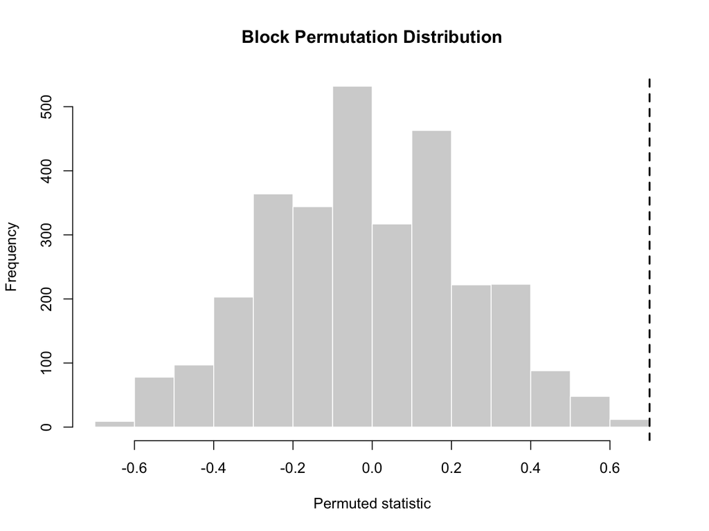

```r
### Now let's get the permutation distribution (under the H0, there is no difference between treatment and controls)
B <- 3000
T_perm <- numeric(B)
blocks <- unique(block_dat$block)

for (b in 1:B) {
  dat_perm <- block_dat

  for (g in blocks) {
    idx <- which(dat_perm$block == g)
    dat_perm$trt[idx] <- sample(dat_perm$trt[idx])
  }

  T_perm[b] <- block_diff(dat_perm)
}

hist(T_perm,
     main = "Block Permutation Distribution",
     xlab = "Permuted statistic",
     col = "lightgray",
     border = "white")
abline(v = T_obs, lwd = 2, lty = 2)
```

```r
mean(abs(T_perm) >= abs(T_obs))
```

```
## [1] 0.007
```

# `aggregate()`: a very useful base R tool

Many structured resampling methods need us to collapse row-level data to a higher level such as:

- cluster means
- stratum summaries

Base R has a built-in function for this: `aggregate()`.

### Common forms

```r
# one grouping variable
aggregate(y ~ trt, data = block_dat, FUN = mean)
```

```
##   trt      y
## 1   A 11.825
## 2   B 11.125
```

```r
# more than one grouping variable
aggregate(y ~ block + trt, data = block_dat, FUN = mean)
```

```
##    block trt    y
## 1      1   A 12.4
## 2      2   A 10.1
## 3      3   A 13.0
## 4      4   A  9.5
## 5      5   A 11.7
## 6      6   A 14.2
## 7      7   A 10.8
## 8      8   A 12.9
## 9      1   B 11.8
## 10     2   B  9.6
## 11     3   B 12.2
## 12     4   B  8.9
## 13     5   B 11.1
## 14     6   B 13.4
## 15     7   B 10.0
## 16     8   B 12.0
```

### Interpretation

- `y ~ trt` means: summarize `y` separately for each treatment group
- `y ~ block + trt` means: summarize `y` for each block-treatment combination

You will often use `aggregate()` before permutation or bootstrap when the observational unit is not the row of the data frame.

# Cluster permutation: idea

Now suppose treatment was assigned at the **cluster** or **block** level.

Examples:

- classrooms assigned to an intervention
- hospitals assigned to a policy
- villages assigned to a program

Then the permutation unit is the **cluster**.

### Cluster permutation

- keep all rows inside a cluster together
- permute treatment labels across clusters
- recompute the statistic

If we permute individual rows instead, we destroy the original randomization design.

# Cluster permutation: example in R

```r
head(school_dat)
```

```
##   school     trt    score
## 1      1 control 70.24189
## 2      1 control 71.03897
## 3      1 control 69.86349
## 4      1 control 70.93158
## 5      1 control 68.51149
## 6      1 control 69.96802
```

```r
str(school_dat)
```

```
## 'data.frame':    72 obs. of  3 variables:
##  $ school: int  1 1 1 1 1 1 1 1 1 1 ...
##  $ trt   : chr  "control" "control" "control" "control" ...
##  $ score : num  70.2 71 69.9 70.9 68.5 ...
```

```r
## collapse to school means
school_means <- aggregate(score ~ school + trt, data = school_dat, FUN = mean)

prog_scores <- school_means$score[school_means$trt == "program"]
ctrl_scores <- school_means$score[school_means$trt == "control"]

T_obs <- mean(prog_scores) - mean(ctrl_scores)

# exact cluster permutations
all_prog_sets <- combn(1:nrow(school_means), 3)

T_perm_exact <- numeric(ncol(all_prog_sets))

for (b in 1:ncol(all_prog_sets)) {
  prog_idx <- all_prog_sets[, b]
  ctrl_idx <- setdiff(1:nrow(school_means), prog_idx)

  T_perm_exact[b] <- mean(school_means$score[prog_idx]) -
                     mean(school_means$score[ctrl_idx])
}

sort(T_perm_exact)
```

```
##  [1] -3.8177558 -2.1355350 -1.9421496 -1.7005620 -1.3379599 -1.1445745
##  [7] -0.9726192 -0.9029870 -0.7792338 -0.5376463  0.5376463  0.7792338
## [13]  0.9029870  0.9726192  1.1445745  1.3379599  1.7005620  1.9421496
## [19]  2.1355350  3.8177558
```

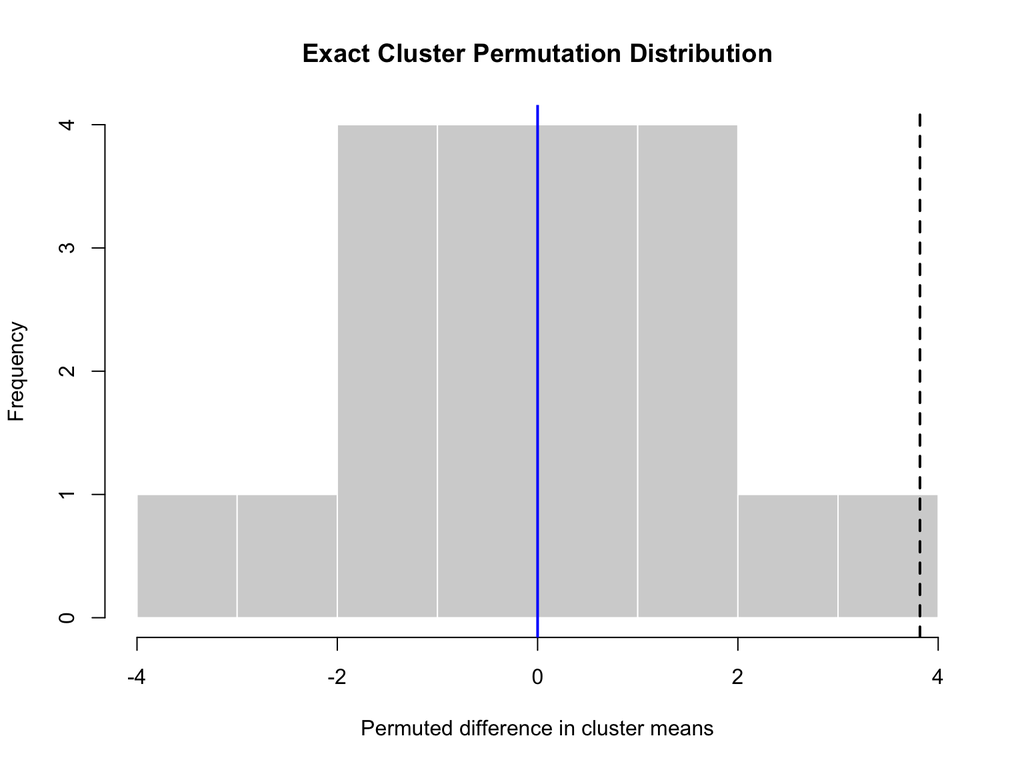

```r
hist(T_perm_exact,
     main = "Exact Cluster Permutation Distribution",
     xlab = "Permuted difference in cluster means",
     col = "lightgray",
     border = "white")
abline(v = 0, lwd = 2, col = "blue")
abline(v = T_obs, lwd = 2, lty = 2)
```

```r
mean(abs(T_perm_exact) >= abs(T_obs))
```

```
## [1] 0.1
```

# Cluster bootstrap: idea

When observations within a cluster are dependent, the bootstrap unit should usually be the **cluster**.

### Cluster bootstrap

- sample clusters **with replacement**
- keep all observations from each selected cluster
- recompute the statistic

This mimics repeated sampling of independent clusters.

### Typical use cases

- repeated measures within subject
- students within school
- patients within clinic

# Cluster bootstrap: example in R

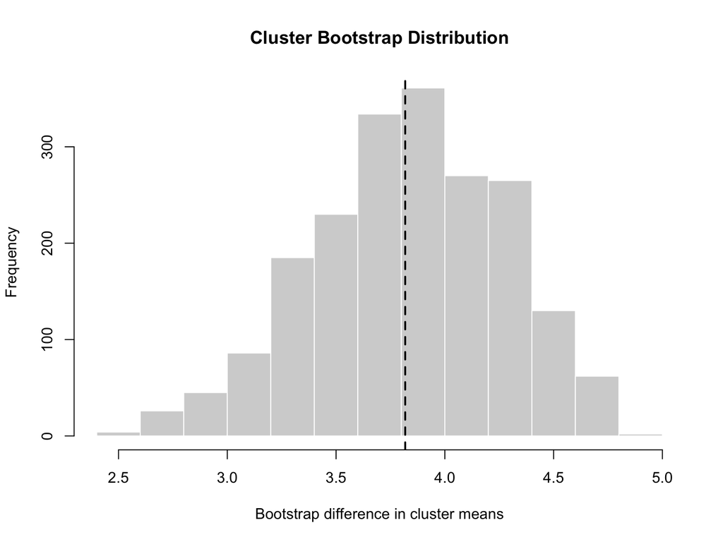

```r
set.seed(321)

# 1. Pre-aggregate to cluster means
cl_means_df <- aggregate(score ~ school + trt, data = school_dat, FUN = mean)
ctrl_means  <- cl_means_df$score[cl_means_df$trt == "control"]
prog_means  <- cl_means_df$score[cl_means_df$trt == "program"]

# 2. Initialize storage
B <- 2000
T_boot <- numeric(B)

# 3. Stratified Bootstrap Loop
set.seed(321) # for reproducibility
for (b in 1:B) {
  # Sample with replacement within each group
  resample_ctrl <- sample(ctrl_means, size = length(ctrl_means), replace = TRUE)
  resample_prog <- sample(prog_means, size = length(prog_means), replace = TRUE)

  # Calculate and store the difference in means
  T_boot[b] <- mean(resample_prog) - mean(resample_ctrl)
}

hist(T_boot,
     main = "Cluster Bootstrap Distribution",
     xlab = "Bootstrap difference in cluster means",
     col = "lightgray",
     border = "white")
abline(v = T_obs, lwd = 2, lty = 2)
```

```r
sd(T_boot)
```

```
## [1] 0.4504037
```

```r
quantile(T_boot, c(0.025, 0.975))
```

```
##    2.5%   97.5%
## 2.83751 4.61670
```

# Common mistakes

A structured resampling method can fail if we choose the wrong unit.

### Examples

- blocked experiment: permuting labels across all rows instead of within block
- cluster-randomized study: permuting individuals instead of clusters
- clustered data: bootstrapping rows instead of clusters

### Takeaway

Always ask: what was the independent unit in the design or sampling process?

### Big picture

Permutation and bootstrap still follow the same logic as before.

The difference is that the resampling unit must match the data structure.